# 1. Introduction to AI

## 1.1. AI as a research field

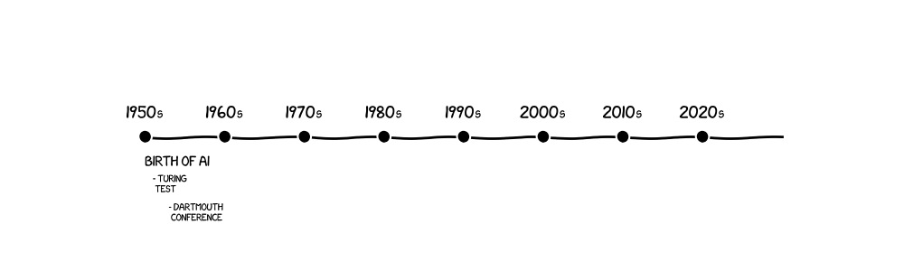

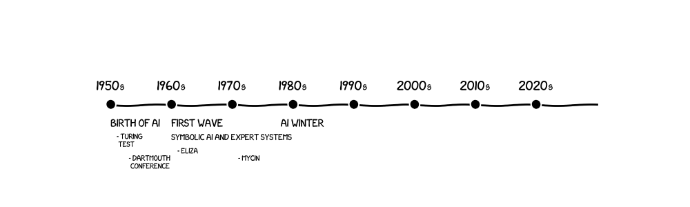

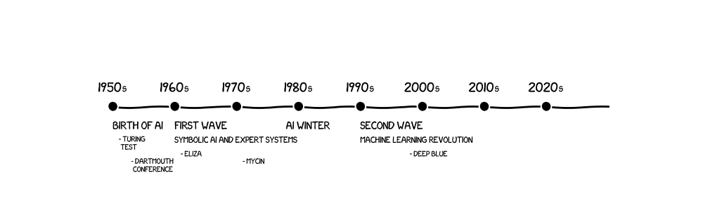

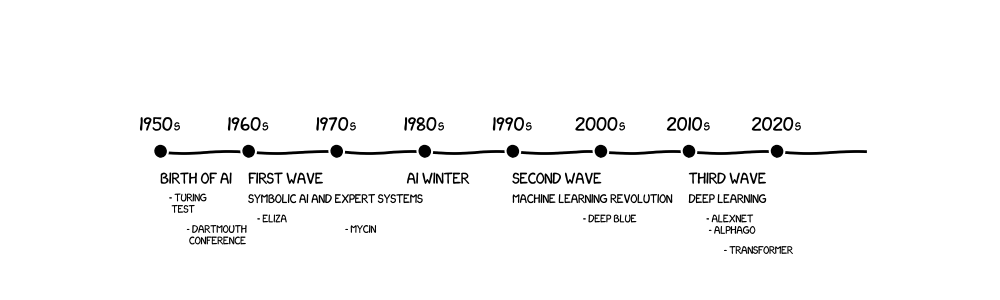

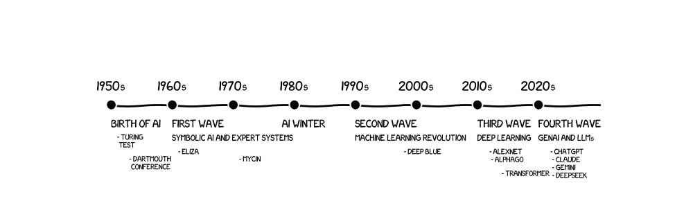

- **Early ambitions (1950s-1960s)**:
  - AI as the quest to create human-like intelligence in machines.
  - The **Turing Test** (Turing, 1950): Can machines think?
  - **Dartmouth Conference** (1956) – the birth of AI as a field.
- **First wave (1950s-1980s): Symbolic AI and expert systems**
  - AI mostly **rule-based**, following **logic** and **heuristics**.
    - Examples: **ELIZA**, chatbot (1960s); **MYCIN** medical diagnosis system (1970s).
  - Limitations: **brittle logic, poor adaptability, lack of learning ability**.
- **AI Winters (1970s, 1980s-1990s)**
  - Overpromises vs. underperformance.
  - Failure of expert systems to scale due to increasing complexity.
  - **Restricted funding.**
- **Second wave (1990s-2010s): Machine Learning revolution**
  - Shift from rule-based AI to **data-driven models**.
  - Rise of **statistical approaches**, including decision trees and neural networks.
  - 1997: **Deep Blue** beats Garry Kasparov in chess.
- **Third wave (2010s-2020s): Deep Learning and modern AI**
  - Explosion of **computing power** and **data**.
  - Breakthrough in **Deep Learning**
    - 2012: **AlexNet** wins the ImageNet competition
  - AI applications expand into speech, vision, and finance (e.g., fraud detection, algorithmic trading).
- **Fourth wave (2020s-present): Generative AI, Large Language Models (LLMs)**
  - The rise of **foundation models** trained on massive datasets (GPT, BERT, Claude, Gemini).
    - 2020: OpenAI introduces **GPT-3**, capable of human-like text generation.
    - 2022: **ChatGPT** launches, sparking mainstream adoption of generative AI.
  - **LLMs in finance:** Used for document processing, risk assessment, and fraud detection.
  - **Regulatory agenda**: misinformation, privacy, AI bias, copyright concerns.

## 1.2. The two AI schools

**Good Old-Fashioned AI (GOFAI) vs Modern AI**

| AI Approach | Description | Strengths | Weaknesses |
| --- | --- | --- | --- |
| **Symbolic AI** | Rules, logic, and symbolic reasoning | - Transparency - Interpretability - Computationally light | - Hard to scale - Inflexible (no learning) - Human efforts |
| **Machine Learning** | Statistical learning w/ or w/o guidance | - Adaptability - Scalability - Learns w/o predefined rules | - Data & computation power - Opacity (“black box”) - Hidden biases |

- **Key distinction**:
  - **Symbolic AI**: explicit programming
    - `If X, then Y`
  - **Machine Learning**: implicit programming
    - `Code how to learn`
- **Example: Language Processing**
  - Symbolic AI: Hard-coded grammar rules.
  - ML: Learns linguistic patterns from tranlsated text corpora (e.g., Google translate, GPT, BERT).

## 1.3. Dominance of Machine Learning

- **ML’s superior performance in key applications**
  - Image recognition (e.g., facial recognition, medical imaging).
  - Natural language processing (e.g., chatbots, voice assistants).
  - Financial applications (e.g., risk assessment, fraud detection).

### Why ML dominates modern AI?

- **Data and computation drive AI progress**
  - Increase in **data availability** (big data, user-generated content).
  - Advances in **computing power** (cloud, GPUs, TPUs).
  - **Algorithmic improvements**
    - **Deep learning**: capacity of neural networks to model complex patterns in data.
- **Limitations remain**
  - **Explainability problem**: Hard to understand how ML models produce outputs.
  - **Data dependency**: Requires large, high-quality datasets.
  - **Ethical concerns**: Bias, fairness, privacy issues.

# 2. Some economics of Machine Learning

## 2.1. The technology of ML

### Economics 101: what is a technology?

A **technology** = a tool that **reduces the cost** of producing some good or service.

Examples:

- The **steam engine** reduced the **cost of transportation and manufacturing**.
- The **printing press** reduced the **cost of information dissemination**.
- **Electricity** reduced the **cost of mechanical power and lighting**.

### What cost does Machine Learning reduce?

**Machine Learning reduces the cost of prediction**

- **Prediction = infer missing data / forecast the future**.
- **Traditionally expensive** due to:
  - Human expertise (analysts, forecasters).
  - Manual data collection and limited statistical modeling.
  - Limited computing power.

### Complements and substitutes of prediction

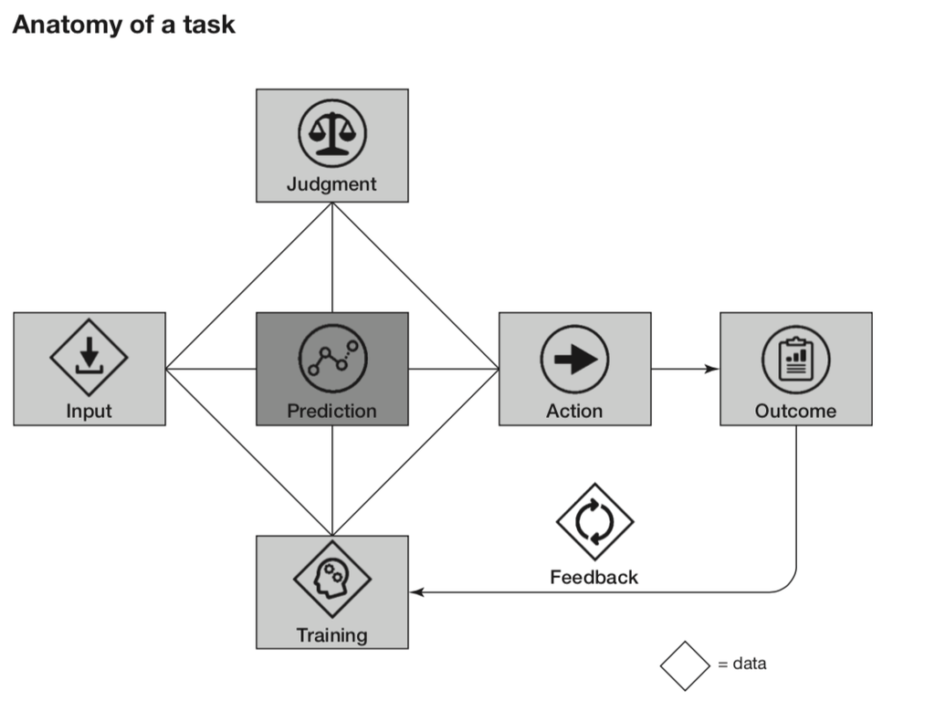

Agrawal, A., Gans, J., & Goldfarb, A. (2022).  
Prediction machines: The simple economics of artificial intelligence. Harvard Business Press.

💡**GenAI = Prediction + Action**💡

### Complements

**Value increases as prediction becomes cheaper**

- **Decision-making**: prediction complements action
  - *Example*: Loan approvals based on AI credit scoring
- **Data labour & access**: more prediction requires more accessible high-quality (labelled) data
  - *Example:* APIs, Google, JPMorgan leverage proprietary data
- **Human expertise (Causality & Strategy)**: focus efforts on understanding *why* & judging outcomes
  - *Example:* Financial analysts, medical professionals
- **Infrastructure & compute power**: GPUs, TPUs, and cloud computing
  - *Example:* NVIDIA (GPUs), AWS (cloud AI)
- **Ethical & regulatory compliance**: access, control and oversight
  - *Example:* GDPR, AI auditing frameworks

### Substitutes

**Value decreases as prediction becomes cheaper**

- **Rules-based systems**: Hardcoded rules lose value compared to ML models
  - *Example:* static `if-then` rules in fraud detection and AML
- **Traditional prediction models**: simple statistical models are replaced by ML
  - *Example:* Linear regression in credit-scoring
- **Human forecasters & analysts**: value of manual pattern recognition may shrink
  - *Example:* Research analysts, financial advisors
- **Redundant or low-quality data**: high-quality data becomes more valuable, reducing demand for outdated datasets
  - *Example:* Qualitative, subjective, static and soft data such as in traditional credit reports

## 2.2. Key complement to ML: Data

### The value of data

1. **Data is the fuel for ML**, improving model accuracy and decision-making.
2. **High-quality, well-labeled data** is often more valuable than just large amounts of raw data.
3. **Regulations and data-sharing frameworks** shape the economics of **AI development**.
4. **Firms with superior access to diverse, high-quality data** have a significant **competitive advantage**.

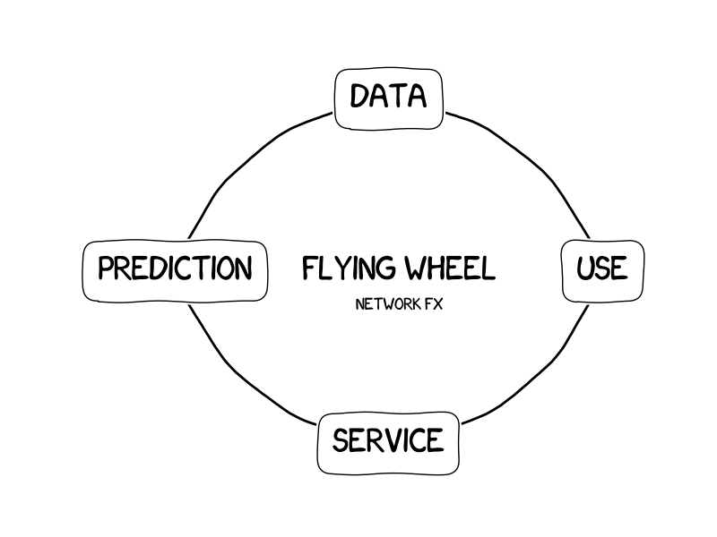

### Economic challenges: data access and ownership

- **Data as a competitive moat:**
  - **Network effects**: Firms with **more data** build better models, attracting more people, etc.
  - **Entry barriers**: firms **hoard data** as a competitive asset, making it difficult for smaller players to enter the market.
  - **Winner-take-all**
- **Privacy and control trade-off:**
  - Firms want **exclusive** access to data for competitive advantage
  - Data sharing is subject to **privacy**
  - Users benefit from **privacy and control**
- **Regulatory response:**
  - **Data Portability & Interoperability** (open data)
    - Allowing consumers to transfer their financial, medical, or social data across platforms without friction.
    - Policy solution: Open Banking & Open Finance aim to reduce data monopolies.
    - Technological solutions: Standardized APIs, federated learning, and decentralized identity systems.
  - **GDPR (Europe) / CCPA (California Consumer Privacy Act):** Protects personal data privacy, imposing strict conditions on data collection and usage.
  - **Policy challenge:** Balancing incentives with fair access.

## 2.3. The limits of ML and “AI snake oil”

### Turning problems into predictions

ML is most effective when problems can be **reframed as prediction tasks** for which **historical data** serves to improve performance.

- **Examples:**
  - **Translation:** Predict the most likely correct translation rather than relying on rules.
  - **Self-driving cars:** Predict human behavior, road conditions, and best navigation decisions.
  - **Finance:** Predict fraud, credit risk, market trends.

### Limits of predictions

- **Not all problems are prediction problems:** Some require reasoning, causality, or logic.
- **Not all prediction problems are ML problems:** Some do not have suitable data to performance the prediction (e.g., early days of COVID-19)
- **Symbolic AI vs ML:**
  - **Symbolic AI** (rule-based) does not need data but lacks adaptability.
  - **ML** requires data but struggles with causality and reasoning.
- **AI Snake Oil Argument (Arvind Narayanan, Princeton):** Some AI solutions are **hyped** but lack real economic value.
  - Example: AI for job interviews, grant allocation → unreliable and pseudoscientific.
- **Lesson:** AI works best where prediction is genuinely useful (i.e., relies on credible data input).

# 3. AI & Finance

## 3.1. The AI bandwagon

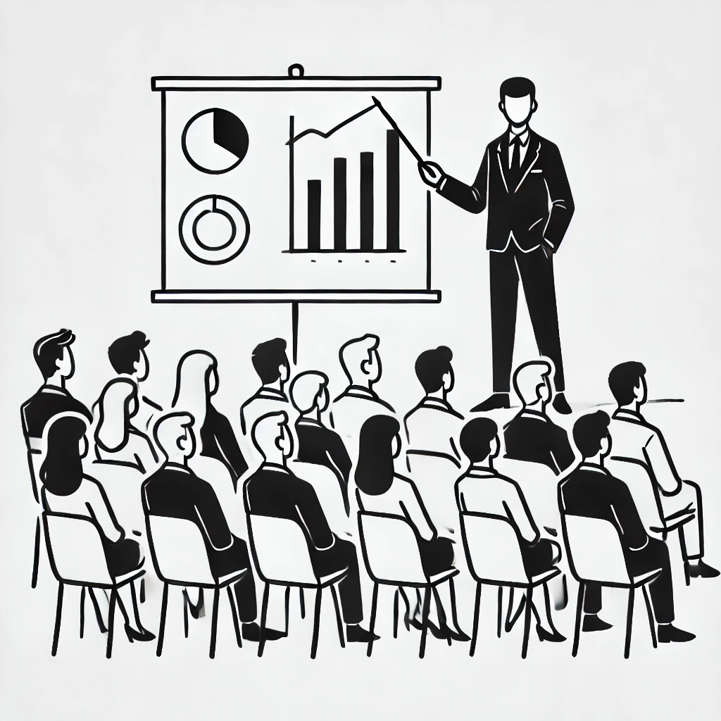

**Consultant speach for any industry**

- **Efficiency Gains**: AI automates processes, reducing operational costs.
- **Better Decision-Making**: AI improves risk assessment and anomaly detection.
- **Enhanced Customer Experience**: Chatbots, personalized recommendations, and automated services.

## 3.2. Prediction in finance

Finance is about the **allocation of capital and risk**.  
The main barrier to achieving an efficient equilibrium is **information frictions**.

### The nature of financial information

In modern economies, information is stored in data.

- **Data production**: digital traces (e.g., transactions), investment/trading behavior, customer details, market signals, sensory data (smart wearables, warehouse trackers, etc.).
- **Information asymmetry**: Institutions have more information than individuals or the other way around.
- **Privacy and confidentiality**: Privacy preferences and regulations (GDPR, PSD2) shape how data is handled.

### The value proposition of AI in Finance

The value proposition of AI in finance is to enhance efficiency by **reducing information problems** through **better prediction**

#### Information frictions

- **Incomplete information**: AI may enhance **forecasting** accuracy, improving financial decision-making.
- **Asymmetric information**: AI may help mitigate issues of:
  - **Screening**: Enhancing credit risk assessment and **adverse selection problems**.
  - **Monitoring**: Detecting anomalous activity and **moral hazard problems**.
- **Complex information**: AI processes vast amounts of structured and unstructured data, and may help identifyi **hidden patterns**.
- **Private/confidential information**: AI may help assist in extracting confidential insights (**triangulation**)

## 3.3. Information-driven business models in finance

### Traditional finance

Traditional financial businesses have long relied on **information** to assess risk, allocate capital, and optimize decision-making.

Examples:

- **Credit Scoring & Lending**: Traditional banks evaluate borrower creditworthiness using **historical financial information**.
- **Investment Advisory**: Financial advisors and wealth management firms analyze **market trends** and client **portfolios**.
- **Trading & Market Making**: Investment banks and hedge funds leverage **proprietary research** and **asset returns** data to execute trades.
- **Fraud & Compliance:** Financial institutions analyze **transaction patterns** and **user behavior** to identify **anomalies**, such as unauthorized transactions or money laundering attempts.

### The integration of AI

Everyone is after it

- **Incumbents** leveraging data access (banks, payments, insurance, asset managers, etc.)
- **Newcomers** exploiting new data opportunities
  - **Fintech** (neo banks, robo advisors, platforms, etc.): alternative data, superior prediction
  - **BigTech** (apple pay, amazon credit, etc.): massive data, superior prediction, computing power, user base

#### Trends

- **Lending**
  - Traditional banking: AI is used to refine profiling and pricing of loan products (**JPMorgan Chase** 1st in AI Evident Index).
  - New businesses:
    - Fintech lending platforms incorporate alternative data for credit scoring (**Rocket Mortgage** for mortgages, **Upstart** for personal/car loans, **Klarna** for BNPL).
    - Peer-to-peer lending platforms leverage AI-driven risk assessment models (**LendingClub**, **Prosper**).
    - BigTech lending leveraging activity data on the platform (**Amazon**).
- **Investment**
  - Wealth management: Robo-advisors apply machine learning to portfolio management and asset allocation (**Betterment** for financial advice, **Wealthfront** for automated investing).
  - Crowdfunding: AI enhances risk assessment in crowdfunding platforms (**Kickstarter**, **Seedrs**).
- **Trading**
  - Algorithmic trading uses AI for market-making and high-frequency trading (**Renaissance Technologies**, **Citadel Securities**).
  - AI-driven sentiment analysis interprets news, reports, and social media for trading insights (**Kavout**).
- **Fraud Detection & Compliance**
  - AI models identify patterns of fraudulent transactions in real-time (**Visa**, **Mastercard**).
  - AI supports compliance efforts in areas such as AML (Anti-Money Laundering) and KYC (Know Your Customer) (**ComplyAdvantage** for AML, **Feedzai** for fraud).

# 4. Challenges

## 4.1. Information barriers

- **Trade-off between data sharing & privacy**: Incentives to share vs. risk of exposure.
- **Data ownership & control**: Who owns financial data—customers or firms?
- **Regulatory uncertainty**: AI compliance in financial markets.

### Open Data policies

- **Open Banking & Open Finance**: Expanding access to financial data.
- **Costs vs. Benefits**: Interoperability challenges, regulatory hurdles, incentives to innovate.
- **Compatibility Issues**: Ensuring seamless integration of AI across financial institutions.

## 4.2 Ethics and fairness

- **Path dependencies and embedded biases**
- **Explainability of ML outcome**
- **Triangulation**
- **Winners and losers of AI adoption**: improving prediction technology has both extensive and intensive margin effects

## 4.4. Toxic data

- **Turing's nightmare**: AI-generated content may contaminate original data.
- **Contribution halt**: AI-usage may block the natural human production of data (e.g., Wikipedia activity drop)
- **AI Model Collapse**: Chained dependence on flawed data may amplify error and destroy information value.
- **Watermarking data**: Preventing AI-generated content from contaminating financial data.

## 4.5. Agentic AI

- **Autonomous AI agents**: When decision is coupled with predictions.
- **Flash crashes & AI-driven volatility**: Historical examples of AI-induced market instability.
- **Algorithmic collusion**

# Final word

## 2 tales on the age of **opaque automation**

### **The Monkey Paw problem**

Prompting AI for unintended financial outcomes.

[figure not shown]

### **The art of air traffic control**

Not because we don't understand everything that we cannot do anything to safeguard and learn

# Thank you!

# Comments from chatgpt

**prompt**: `what do you think of the overall structure of my lecture - any suggestions?`

Your lecture structure is strong and well-organized, covering key aspects of AI, its economic implications, and its applications in finance. However, I have a few suggestions to improve flow, depth, and clarity:

Strengths of Your Structure

✅ Logical progression: You start with AI fundamentals, move to economics, then finance-specific applications, and conclude with challenges. ✅ Balanced mix of technical and policy-relevant content: This suits policymakers well. ✅ Covers critical policy topics: Open banking, privacy, information barriers, and toxic data are well chosen.

Suggestions for Improvement

1. Strengthen the Transition Between Sections • Current gap: There’s no explicit transition from machine learning economics to AI in finance. • Fix: Add a short section like “AI’s Economic Impact on Financial Services” to bridge them. • Why finance is particularly suited for AI (data-rich, highly regulated, risk-sensitive). • How prediction improvements disrupt financial decision-making (credit scoring, fraud detection).
2. Expand the “Economics of Machine Learning” Section • Add a subtopic: The Value of Data & Network Effects • How firms with more data gain an advantage (data flywheels). • Why first movers (Google, Apple, JPMorgan) maintain dominance. • The role of data monopolies and regulatory concerns (good segue to policy discussions later). • Clarify the link between ML and automation: • Machine learning isn’t just reducing prediction costs; it also enables decision automation. • Tie this to Agentic AI in challenges.
3. “AI in Finance” Could Benefit from More Industry-Specific Examples • Instead of general claims, use concrete examples for each concept. • Information frictions: AI-powered credit scoring (e.g., Upstart, Zest AI). • Data-driven business models: JPMorgan’s use of AI for trade surveillance. • Privacy issues: Facial recognition for KYC compliance (China’s use vs. EU regulations).
4. “Challenges” Section: Improve Flow & Clarify Key Trade-offs • The trade-off between privacy and data availability could be more structured: • Fundamental tension: AI thrives on more data, but finance relies on data protection. • Regulatory approaches: GDPR, Open Banking, decentralized identity (ZKP, self-sovereign identity). • Potential solutions: Data anonymization, synthetic data, federated learning. • Toxic Data: • Currently, it focuses on AI-generated content (Turing test, model collapse). • Suggestion: Broaden it to include data poisoning attacks & adversarial ML (critical for finance). • Agentic AI: • The “Golem/Monkey Paw” metaphor is great! Consider adding real-world analogies: • AI-driven trading algorithms causing flash crashes. • AI chatbots making unauthorized financial transactions.

Final Thoughts

Your structure is very strong, but with a few refinements: ✅ Better transitions between sections → smoother flow. ✅ More industry-specific finance examples → clearer policy implications. ✅ Stronger focus on regulatory and ethical trade-offs → more value for policymakers.

Would you like me to help rewrite or reformat any sections based on these suggestions? 🚀

# Code

### Flywheel graph

```python
# Re-import necessary libraries after execution state reset
import matplotlib.pyplot as plt
import numpy as np

# Enable XKCD style for hand-drawn effect
plt.xkcd()

# Define the flywheel stages
stages = ["USE", "DATA", "PREDICTION", "SERVICE"]

# Define positions in a circular layout
theta = np.linspace(0, 2 * np.pi, len(stages), endpoint=False)
x = np.cos(theta)
y = np.sin(theta)

# Create figure and axis
fig, ax = plt.subplots(figsize=(8, 6))
ax.set_xlim(-1.4, 1.2)
ax.set_ylim(-1.2, 1.2)
ax.set_xticks([])
ax.set_yticks([])
ax.set_frame_on(False)

# Draw curved arrows connecting the nodes
for i in range(len(stages)):
    start_x, start_y = x[i], y[i]
    end_x, end_y = x[(i + 1) % len(stages)], y[(i + 1) % len(stages)]
    ax.annotate("", xy=(end_x, end_y), xytext=(start_x, start_y),
                arrowprops=dict(arrowstyle='-|>', connectionstyle="arc3,rad=0.3", lw=2, color='black'))

# Draw nodes (circles) and labels
for i, stage in enumerate(stages):
    ax.text(x[i], y[i], stage, fontsize=24, ha='center', va='center',
            bbox=dict(facecolor='white', edgecolor='black', boxstyle='round,pad=0.5'))

    ax.text(0.05, 0, "FLYING WHEEL", fontsize=24, ha='center', va='center')
    ax.text(0.05, -0.2, "NETWORK FX", fontsize=12, ha='center', va='center')

# plt.show()
plt.savefig("flywheel.png")
```

### Timeline graph

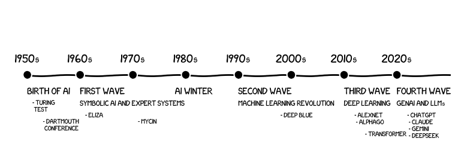

```python
# Re-import necessary libraries after execution state reset
import matplotlib.pyplot as plt
import numpy as np

# Enable XKCD style for hand-drawn effect
plt.xkcd()

# Define the flywheel stages
stages = ["1950s","1960s","1970s","1980s","1990s","2000s","2010s", "2020s", ""]

# Create a figure and axis
fig, ax = plt.subplots(figsize=(10, 3))

# Define x positions for stages
x = np.arange(len(stages))
y = np.zeros(len(stages))  # same y-level for all points



# Annotate each stage
for i, stage in enumerate(stages):
    ax.text(x[i], y[i] + 0.01, stage, ha='center', fontsize=12)

# --- Add annotations below the line ---

# BIRTH
ax.text(x[0], y[0] -0.01, "BIRTH OF AI",
        ha='left', va='top', fontsize=10)
ax.text(x[0] + 0.1, y[0] -0.02, "- TURING \n TEST",
        ha='left', va='top', fontsize=7)
ax.text(x[0] + 0.3, y[0] -0.035, "- DARTMOUTH \n CONFERENCE",
        ha='left', va='top', fontsize=7)

# FIRST WAVE
ax.text(x[1] , y[0] -0.01, "FIRST WAVE",
        ha='left', va='top', fontsize=10)
ax.text(x[1] , y[0] -0.02, "SYMBOLIC AI AND EXPERT SYSTEMS",
        ha='left', va='top', fontsize=8)
ax.text(x[1]+ 0.1 , y[0] -0.03, "- ELIZA",
        ha='left', va='top', fontsize=7)
ax.text(x[2]+ 0.1 , y[0] -0.035, "- MYCIN",
        ha='left', va='top', fontsize=7)
ax.text(x[2] + 0.8 , y[0] -0.01, "AI WINTER",
        ha='left', va='top', fontsize=10)

# SECOND WAVE
ax.text(x[4] , y[0] -0.01, "SECOND WAVE",
        ha='left', va='top', fontsize=10)
ax.text(x[4] , y[0] -0.02, "MACHINE LEARNING REVOLUTION",
        ha='left', va='top', fontsize=8)
ax.text(x[5]- 0.2 , y[0] -0.03, "- DEEP BLUE",
        ha='left', va='top', fontsize=7)

# THIRD WAVE
ax.text(x[6] , y[0] -0.01, "THIRD WAVE",
        ha='left', va='top', fontsize=10)
ax.text(x[6] , y[0] -0.02, "DEEP LEARNING",
        ha='left', va='top', fontsize=8)
# ax.text(x[4] , y[0] -0.02, "MACHINE LEARNING REVOLUTION",
        # ha='left', va='top', fontsize=8)
ax.text(x[6]+ 0.2 , y[0] -0.03, "- ALEXNET \n - ALPHAGO",
        ha='left', va='top', fontsize=7)
ax.text(x[6]+ 0.4 , y[0] -0.045, "- TRANSFORMER",
        ha='left', va='top', fontsize=7)

# FOURTH WAVE
ax.text(x[7] , y[0] -0.01, "FOURTH WAVE",
        ha='left', va='top', fontsize=10)
ax.text(x[7] , y[0] -0.02, "GENAI AND LLMs",
        ha='left', va='top', fontsize=8)
ax.text(x[7]+ 0.2 , y[0] -0.03, "- CHATGPT\n - CLAUDE\n - GEMINI\n - DEEPSEEK",
        ha='left', va='top', fontsize=7)

# Plot stages as points
ax.plot(x, y, 'k-', markersize=8)
ax.plot(x[:-1], y[:-1], 'ko', markersize=8)

# Remove y-axis and tidy up
ax.get_yaxis().set_visible(False)
ax.spines['left'].set_visible(False)
ax.spines['right'].set_visible(False)
ax.spines['top'].set_visible(False)

# Set x limits to fit all labels nicely
# ax.set_xlim(-0.5, len(stages) - 0.5)

# Remove x-axis completely
ax.get_xaxis().set_visible(False)  # Hides tick labels
ax.spines['bottom'].set_visible(False)  # Hides x-axis line

# Show the plot
# plt.show()
plt.savefig("timeline5.png")
```